# Project_mid_Group_10

#### Ridwan Ahmed Arman (21-44504-1)

#### Nafis Alam Siddiquee (20-43218-1)

## Dataset Description

The Diabetes Prediction Dataset include patient medical and demographic information as well as the state of their diabetes (positive or negative). Features like age, gender, blood glucose level, smoking history, hypertension, heart disease, body mass index (BMI), and HbA1c level are among the features included in the data. Using this dataset and patient demographics and medical histories, machine learning models can be developed to predict diabetes in patients. Healthcare providers may find this helpful in identifying individuals who may be at risk of diabetes and in creating individualized treatment regimens. Researchers can also utilize the dataset to investigate the associations between different demographic and medical characteristics and the risk of developing diabetes.

Main dataset https://www.kaggle.com/datasets/iammustafatz/diabetes-prediction-dataset.

Loading packages

```r
library(tidyverse)
library(skimr)
```

Load Dataset

```r
sample_data <- read_csv("/home/ridwan/Documents/aiub/data science/Dataset_MIdterm_sectoin(B).csv")
```

Reviewing the dataset

```r
head(sample_data)
```

```
## # A tibble: 6 × 9
##   gender   age hypertension heart_disease smoking_history   bmi HbA1c_level
##   <chr>  <dbl>        <dbl>         <dbl> <chr>           <dbl>       <dbl>
## 1 Female    80            0             1 never            25.2         6.6
## 2 Female    54            0             0 No Info          27.3         6.6
## 3 Male      28            0             0 never           -27.3         5.7
## 4 Female    NA            0             0 current          23.4         5
## 5 Male      76            1             1 current          20.1         4.8
## 6 Female    20            0             0 never            27.3         6.6
## # ℹ 2 more variables: blood_glucose_level <dbl>, diabetes <dbl>
```

Checking Datatypes

```r
str(sample_data)
```

```
## spc_tbl_ [120 × 9] (S3: spec_tbl_df/tbl_df/tbl/data.frame)
##  $ gender             : chr [1:120] "Female" "Female" "Male" "Female" ...
##  $ age                : num [1:120] 80 54 28 NA 76 20 79 42 32 53 ...
##  $ hypertension       : num [1:120] 0 0 0 0 1 0 0 0 0 0 ...
##  $ heart_disease      : num [1:120] 1 0 0 0 1 0 0 0 0 0 ...
##  $ smoking_history    : chr [1:120] "never" "No Info" "never" "current" ...
##  $ bmi                : num [1:120] 25.2 27.3 -27.3 23.4 20.1 ...
##  $ HbA1c_level        : num [1:120] 6.6 6.6 5.7 5 4.8 6.6 5.7 4.8 5 6.1 ...
##  $ blood_glucose_level: num [1:120] 140 80 158 155 155 85 85 145 100 85 ...
##  $ diabetes           : num [1:120] 0 0 0 0 0 0 0 0 0 0 ...
##  - attr(*, "spec")=
##   .. cols(
##   ..   gender = col_character(),
##   ..   age = col_double(),
##   ..   hypertension = col_double(),
##   ..   heart_disease = col_double(),
##   ..   smoking_history = col_character(),
##   ..   bmi = col_double(),
##   ..   HbA1c_level = col_double(),
##   ..   blood_glucose_level = col_double(),
##   ..   diabetes = col_double()
##   .. )
##  - attr(*, "problems")=<externalptr>
```

Summary of the dataset

```r
skim_without_charts(sample_data)
```

Data summary

| Name | sample_data |
| --- | --- |
| Number of rows | 120 |
| Number of columns | 9 |
| _______________________ |  |
| Column type frequency: |  |
| character | 2 |
| numeric | 7 |
| ________________________ |  |
| Group variables | None |

**Variable type: character**

| skim_variable | n_missing | complete_rate | min | max | empty | n_unique | whitespace |
| --- | --- | --- | --- | --- | --- | --- | --- |
| gender | 2 | 0.98 | 4 | 6 | 0 | 2 | 0 |
| smoking_history | 3 | 0.98 | 4 | 11 | 0 | 6 | 0 |

**Variable type: numeric**

| skim_variable | n_missing | complete_rate | mean | sd | p0 | p25 | p50 | p75 | p100 |
| --- | --- | --- | --- | --- | --- | --- | --- | --- | --- |
| age | 4 | 0.97 | 54.17 | 37.20 | 3.00 | 40.00 | 52.50 | 68.25 | 290.00 |
| hypertension | 2 | 0.98 | 0.08 | 0.28 | 0.00 | 0.00 | 0.00 | 0.00 | 1.00 |
| heart_disease | 0 | 1.00 | 0.07 | 0.25 | 0.00 | 0.00 | 0.00 | 0.00 | 1.00 |
| bmi | 0 | 1.00 | 27.66 | 8.83 | -27.32 | 24.73 | 27.32 | 29.53 | 63.48 |
| HbA1c_level | 0 | 1.00 | 6.28 | 1.38 | 3.50 | 5.70 | 6.20 | 6.65 | 9.00 |
| blood_glucose_level | 0 | 1.00 | 156.75 | 50.73 | 80.00 | 130.00 | 155.00 | 160.00 | 300.00 |
| diabetes | 0 | 1.00 | 0.43 | 0.50 | 0.00 | 0.00 | 0.00 | 1.00 | 1.00 |

## Missing values and outliner

Find number of missing variables column wise

```r
apply(sample_data, MARGIN = 2, FUN = function(x) sum(is.na(x)))
```

```
##              gender                 age        hypertension       heart_disease
##                   2                   4                   2                   0
##     smoking_history                 bmi         HbA1c_level blood_glucose_level
##                   3                   0                   0                   0
##            diabetes
##                   0
```

Replacing missing values of gender

```r
length(which(sample_data$gender=="Male"))
```

```
## [1] 47
```

```r
length(which(sample_data$gender=="Female"))
```

```
## [1] 71
```

```r
sample_data$gender <- sample_data$gender %>% replace_na('Female')
```

Replacing missing values of smoking_history by No info

```r
sample_data$smoking_history <- sample_data$smoking_history %>% replace_na("No Info")
```

Replacing missing values of hypertension and age with median as there may be outliers

```r
sample_data <- sample_data%>% mutate(across(hypertension, ~replace_na(hypertension, median(hypertension, na.rm=TRUE))))
```

```r
sample_data <- sample_data%>% mutate(across(age, ~replace_na(age, median(age, na.rm=TRUE))))
```

Checking if there any missing value left

```r
sum(is.na(sample_data))
```

```
## [1] 0
```

Storing sample_data in sample_2

```r
sample_data2 <- sample_data
```

Boxplot for age to detect outliers

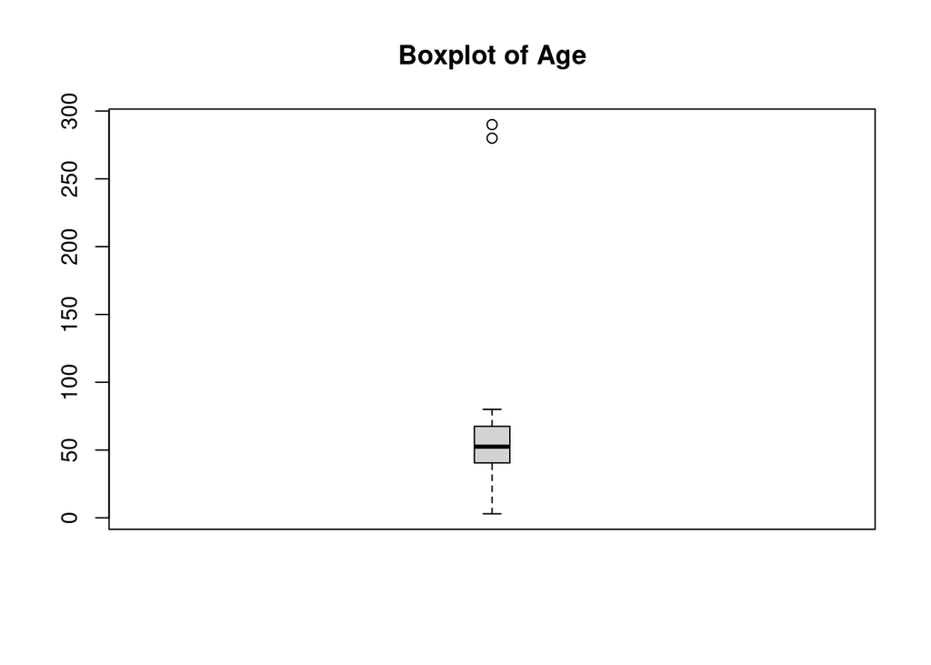

```r
boxplot(sample_data2$age , main= "Boxplot of Age" , boxwex=0.1)
```

Finding outline values

```r
sample_data2$age[sample_data2$age > 150]
```

```
## [1] 290 280
```

Replacing with mean

```r
sample_data2$age[sample_data2$age==280] <- 54
sample_data2$age[sample_data2$age==290] <- 54
```

Boxplot for BMI to detect outliers

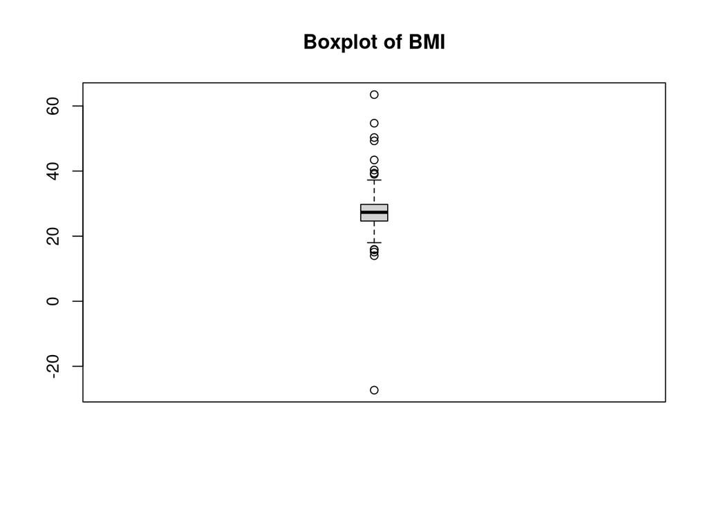

```r
boxplot(sample_data2$bmi , main= "Boxplot of BMI" , boxwex=0.1)
```

Finding outline values

```r
sample_data2$bmi[sample_data2$bmi < 0]
```

```
## [1] -27.32
```

Making to positive

```r
sample_data2$bmi[sample_data2$bmi==-27.32] <- 27.32
```

Checking outliner in hypertension and heart diseade column

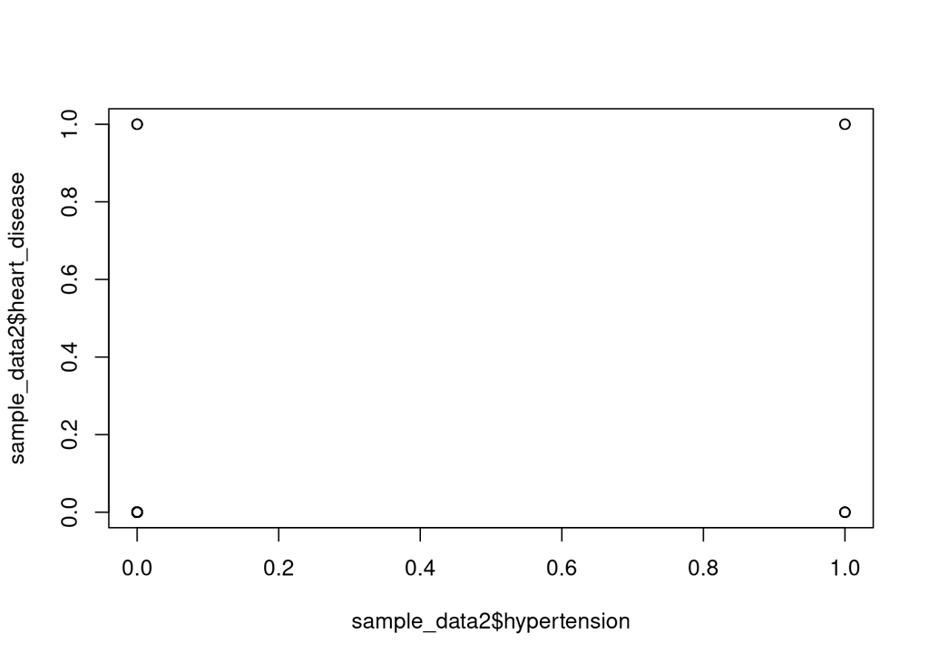

```r
plot(sample_data2$hypertension, sample_data2$heart_disease)
```

Checking outliner in blood_glucose_level

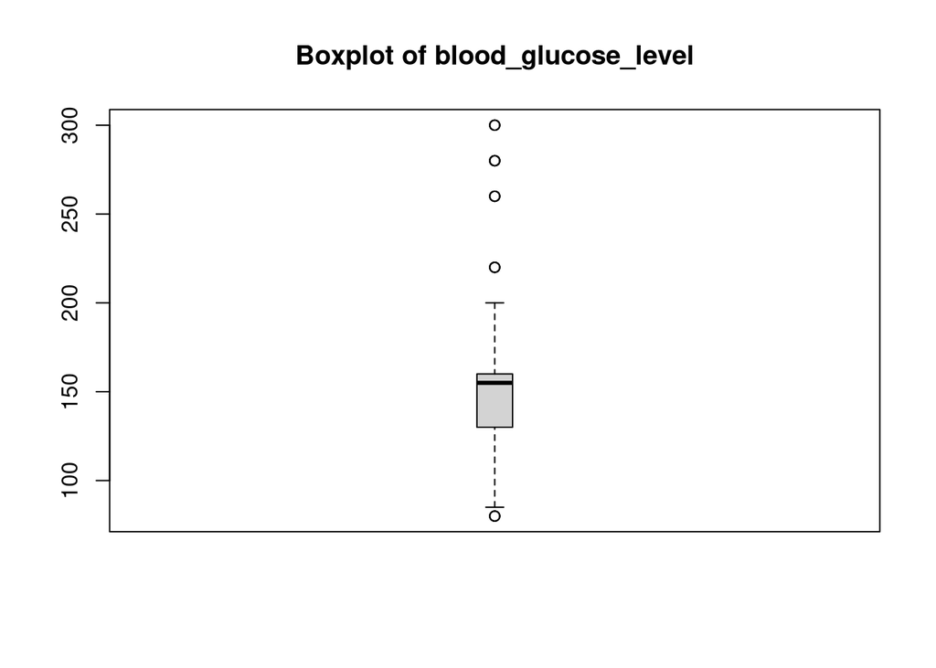

```r
boxplot(sample_data2$blood_glucose_level , main= "Boxplot of blood_glucose_level" , boxwex=0.1)
```

## Graph

Storing sample2 in diabetes data set

```r
diabetes_data <- sample_data2
```

Visualize the gender based on age

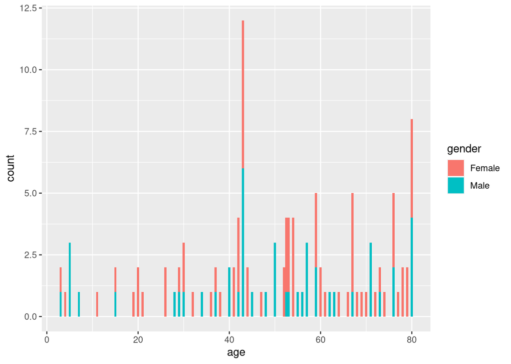

```r
ggplot(data = diabetes_data) +
geom_bar(mapping = aes(x = age, fill= gender))
```

Visualize diabetes based on age and gender

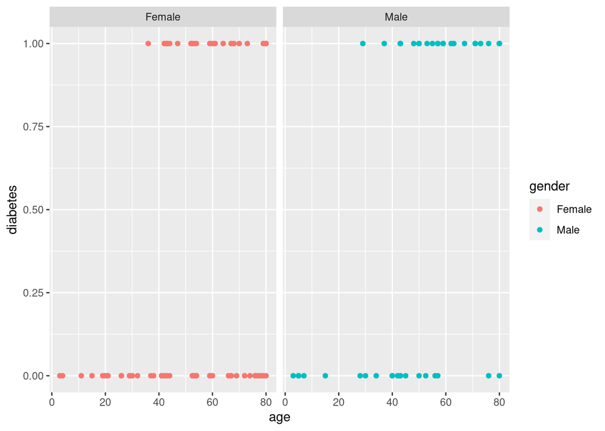

```r
ggplot(data = diabetes_data, aes(x=age,y=diabetes))+ geom_point(aes(color=gender))+ facet_wrap(~gender)
```

Visualize smoking history based on gender

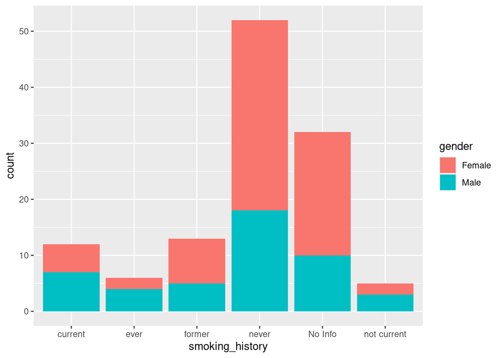

```r
ggplot(data = diabetes_data)+ geom_bar(mapping = aes(x=smoking_history, fill=gender))
```

Visualize BMI based on gender and age

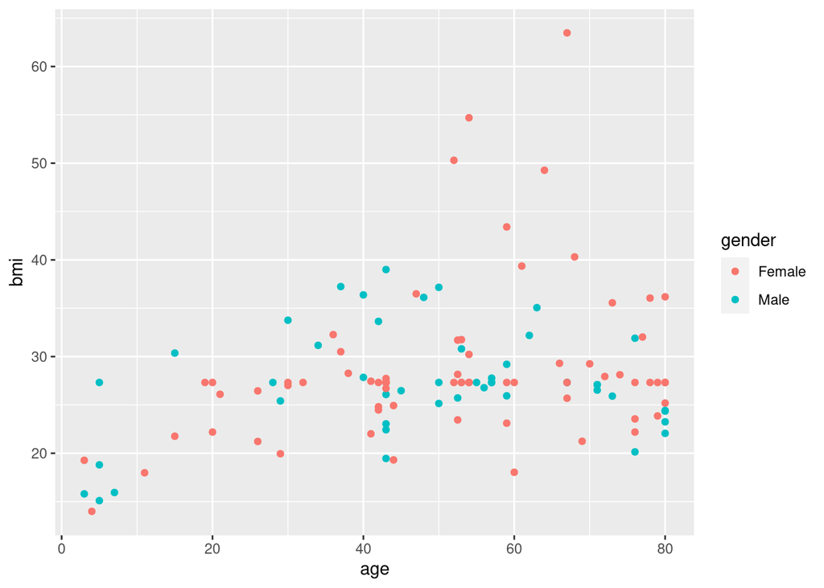

```r
ggplot(data = diabetes_data, aes(x=age,y=bmi))+ geom_point(aes(color=gender))
```

```r
library(knitr)
```